# 05 - Other ANOVA designs part 2

Francisco E. Fonturbel

28/September/2025

## Nested ANOVA

In some opportunities, we have more than one factor explaining our response variable. If those factors are independent, we simply use a two-way ANOVA design, but what if one factor is a subset of the other? Let’s imagine that we measured plant diameter in three populations, and at each population we set three experimental treatments: control, half water and 10% water. So, we will have the water treatment factor nested within the population factor. Thus, each treatment constitutes a sub-replicate of each population replicate. Therefore, it won’t be correct to treat this as a two-way ANOVA; we need to use a Nested ANOVA design instead.

**Key concept:** In nested designs, the levels of one factor (e.g., sites) are unique within each level of another factor (e.g., valleys). This is different from crossed designs where all combinations of factors are possible.

Let’s see some example data:

```r
#Loading packages
library(ggplot2)
library(dplyr)
library(car) # For Type II/III ANOVA

#Let's load the data file
data<-read.table("data/05-infest.txt", header = T)
attach(data)

data$valley <- factor(data$valley, ordered=T)
data$site <-factor(data$site, ordered=T)
```

```r
data
```

```
##    valley      site infestation
## 1   elqui    vicuna           2
## 2   elqui    vicuna           3
## 3   elqui    vicuna           4
## 4   elqui    vicuna           7
## 5   elqui    vicuna           8
## 6   elqui    vicuna           2
## 7   elqui    vicuna           4
## 8   elqui    vicuna           5
## 9   elqui    vicuna           3
## 10  elqui cochiguaz           5
## 11  elqui cochiguaz           6
## 12  elqui cochiguaz           5
## 13  elqui cochiguaz           2
## 14  elqui cochiguaz           6
```

[output cut: 25 more lines]

As you may see in the example data, we have two valleys (Elqui and Limari) and within each valley we have two sampling sites in which we measured cockroach infestation (ewww!). So, we need to nest `site` within `valley` to properly analyze our data.

Let’s first check our experimental design balance:

```r
# Check the structure of our nested design
table(data$valley, data$site)
```

```
##
##          cochiguaz Mpatria Ovalle vicuna
##   elqui         10       0      0      9
##   limari         0      10     10      0
```

```r
# Summary statistics by groups
data %>%
  group_by(valley, site) %>%
  summarise(n = n(),
            mean_infest = mean(infestation),
            sd_infest = sd(infestation),
            .groups = 'drop')
```

```
## # A tibble: 4 × 5
##   valley site          n mean_infest sd_infest
##   <ord>  <ord>     <int>       <dbl>     <dbl>
## 1 elqui  cochiguaz    10        6.1       1.91
## 2 elqui  vicuna        9        4.22      2.11
## 3 limari Mpatria      10       16.9       1.91
## 4 limari Ovalle       10       14.1       2.33
```

Now let’s fit a nested ANOVA model:

```r
replications(~ valley * site, data)
```

```
## $valley
## valley
##  elqui limari
##     19     20
##
## $site
## site
## cochiguaz   Mpatria    Ovalle    vicuna
##        10        10        10         9
##
## $`valley:site`
##         site
## valley   cochiguaz Mpatria Ovalle vicuna
##   elqui         10       0      0      9
##   limari         0      10     10      0
```

```r
aov.infest <- aov(infestation ~ valley/site)
```

OK, now we have an object called `aov.infest`, now we’ll use the `summary()` function to see the results:

```r
summary(aov.infest)
```

```
##             Df Sum Sq Mean Sq F value  Pr(>F)
## valley       1 1031.6  1031.6 240.294 < 2e-16 ***
## valley:site  2   55.9    28.0   6.511 0.00394 **
## Residuals   35  150.3     4.3
## ---
## Signif. codes:  0 '***' 0.001 '**' 0.01 '*' 0.05 '.' 0.1 ' ' 1
```

Our results indicate that infestation height is **significantly different** among valleys and sampling sites within valleys. Notice how the F-test for sites uses the residual error as denominator, which is appropriate for this nested design.

Another thought… what if we want to know which sites explain the differences? Let me introduce you the *a posteriori* tests, which are commonly used to explain pairwise differences in ANOVA models. One of the most famous *a posteriori* tests is the Tukey test, which can be summoned using the `TukeyHSD` function. Let’s see:

```r
TukeyHSD(aov.infest)
```

```
##   Tukey multiple comparisons of means
##     95% family-wise confidence level
##
## Fit: aov(formula = infestation ~ valley/site)
##
## $valley
##                  diff      lwr      upr p adj
## limari-elqui 10.28947 8.941936 11.63701     0
##
## $`valley:site`
##                                        diff        lwr        upr     p adj
## limari:cochiguaz-elqui:cochiguaz         NA         NA         NA        NA
## elqui:Mpatria-elqui:cochiguaz            NA         NA         NA        NA
## limari:Mpatria-elqui:cochiguaz    10.800000   7.815499 13.7845009 0.0000000
## elqui:Ovalle-elqui:cochiguaz             NA         NA         NA        NA
## limari:Ovalle-elqui:cochiguaz      8.000000   5.015499 10.9845009 0.0000000
## elqui:vicuna-elqui:cochiguaz      -1.877778  -4.944061  1.1885054 0.5136627
## limari:vicuna-elqui:cochiguaz            NA         NA         NA        NA
## elqui:Mpatria-limari:cochiguaz           NA         NA         NA        NA
## limari:Mpatria-limari:cochiguaz          NA         NA         NA        NA
## elqui:Ovalle-limari:cochiguaz            NA         NA         NA        NA
## limari:Ovalle-limari:cochiguaz           NA         NA         NA        NA
## elqui:vicuna-limari:cochiguaz            NA         NA         NA        NA
## limari:vicuna-limari:cochiguaz           NA         NA         NA        NA
## limari:Mpatria-elqui:Mpatria             NA         NA         NA        NA
## elqui:Ovalle-elqui:Mpatria               NA         NA         NA        NA
## limari:Ovalle-elqui:Mpatria              NA         NA         NA        NA
## elqui:vicuna-elqui:Mpatria               NA         NA         NA        NA
## limari:vicuna-elqui:Mpatria              NA         NA         NA        NA
## elqui:Ovalle-limari:Mpatria              NA         NA         NA        NA
## limari:Ovalle-limari:Mpatria      -2.800000  -5.784501  0.1845009 0.0791120
## elqui:vicuna-limari:Mpatria      -12.677778 -15.744061 -9.6114946 0.0000000
## limari:vicuna-limari:Mpatria             NA         NA         NA        NA
## limari:Ovalle-elqui:Ovalle               NA         NA         NA        NA
## elqui:vicuna-elqui:Ovalle                NA         NA         NA        NA
## limari:vicuna-elqui:Ovalle               NA         NA         NA        NA
## elqui:vicuna-limari:Ovalle        -9.877778 -12.944061 -6.8114946 0.0000000
## limari:vicuna-limari:Ovalle              NA         NA         NA        NA
## limari:vicuna-elqui:vicuna               NA         NA         NA        NA
```

Well, some comparisons appear marked as “NA” (which represents **missing values** in R jargon). Why there are missing comparisons? because we have nested factors! of course! we cannot compare sites that are in other valleys - Site 1 in Elqui valley is completely different from Site 1 in Limari valley.

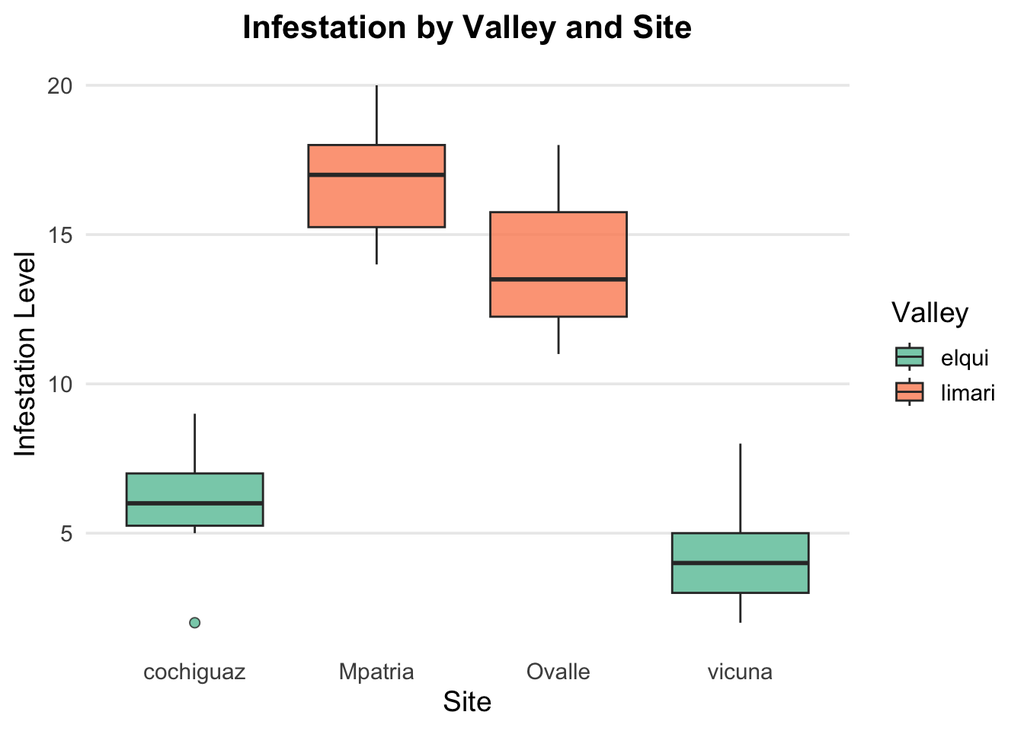

```r
# Let's visualize our nested design
ggplot(data, aes(x = site, y = infestation, fill = valley)) +
  geom_boxplot(alpha = 0.8, outlier.shape = 21, outlier.size = 2) +
  scale_fill_brewer(palette = "Set2", name = "Valley") +
  labs(
    title = "Infestation by Valley and Site",
    x = "Site",
    y = "Infestation Level"
  ) +
  theme_minimal(base_size = 14) +
  theme(
    plot.title = element_text(hjust = 0.5, face = "bold", size = 16),
    legend.position = "right",
    panel.grid.major.x = element_blank(),
    panel.grid.minor = element_blank()
  )
```

## Factorial ANOVA

Until now we have operated with **fixed factors**. A fixed factor is a categorical variable from which we have total control and we have measured all its levels of interest. But not everything can be labeled as a fixed factor in nature. We may have other confounding factors that can be affecting our results, but we have no control over them and/or we have (or cannot) measured all levels. Those factors are called **random factors**.

### Understanding Factor Types

**Fixed factors:** - Levels are specifically chosen by the researcher - Inference applies only to the tested levels - Examples: specific treatments, particular species, chosen temperatures

**Random factors:** - Levels are randomly sampled from a larger population - Inference extends to the entire population of levels - Examples: randomly selected individuals, random sampling locations, random time periods

### Factorial ANOVA Models

In Factorial ANOVA designs we have three possible model types:

1. **Model I (Fixed Effects Model):** Have only fixed factors.
2. **Model II (Random Effects Model):** Have only random factors.
3. **Model III (Mixed Effects Model):** Have a mixture of fixed and random factors.

Let’s use an example from Quinn (1988), in which we have the mean number of eggs as a response variable with two factors: season (fixed factor) and density treatments (fixed factor).

```r
dataf<-read.csv("data/05-quinn.csv", header = TRUE, sep = ",")
attach(dataf)

# Convert to factors and check structure
dataf$SEASON <- factor(dataf$SEASON)
dataf$DENSITY <- factor(dataf$DENSITY)

str(dataf)
```

```
## 'data.frame':    24 obs. of  3 variables:
##  $ DENSITY: Factor w/ 4 levels "8","15","30",..: 1 1 1 1 1 1 2 2 2 2 ...
##  $ SEASON : Factor w/ 2 levels "spring","summer": 1 1 1 2 2 2 1 1 1 2 ...
##  $ EGGS   : num  2.88 2.62 1.75 2.12 1.5 ...
```

```r
head(dataf)
```

```
##   DENSITY SEASON  EGGS
## 1       8 spring 2.875
## 2       8 spring 2.625
## 3       8 spring 1.750
## 4       8 summer 2.125
## 5       8 summer 1.500
## 6       8 summer 1.875
```

### Exploratory Data Analysis

Before diving into the analysis, let’s explore our data:

```r
# Summary statistics
dataf %>%
  group_by(SEASON, DENSITY) %>%
  summarise(n = n(),
            mean_eggs = mean(EGGS),
            sd_eggs = sd(EGGS),
            se_eggs = sd(EGGS)/sqrt(n()),
            .groups = 'drop')
```

```
## # A tibble: 8 × 6
##   SEASON DENSITY     n mean_eggs sd_eggs se_eggs
##   <fct>  <fct>   <int>     <dbl>   <dbl>   <dbl>
## 1 spring 8           3     2.42    0.591   0.341
## 2 spring 15          3     2.18    0.379   0.219
## 3 spring 30          3     1.57    0.621   0.359
## 4 spring 45          3     1.20    0.190   0.110
## 5 summer 8           3     1.83    0.315   0.182
## 6 summer 15          3     1.18    0.482   0.278
## 7 summer 30          3     0.811   0.411   0.238
## 8 summer 45          3     0.593   0.205   0.118
```

```r
# Check for balance in our design
table(dataf$SEASON, dataf$DENSITY)
```

```
##
##          8 15 30 45
##   spring 3  3  3  3
##   summer 3  3  3  3
```

### Step-by-step Analysis

Let’s start by fitting individual models for each factor to understand their independent effects:

```r
aov.season<-aov(EGGS~SEASON, data = dataf)
summary(aov.season)
```

```
##             Df Sum Sq Mean Sq F value  Pr(>F)
## SEASON       1  3.250    3.25    8.55 0.00786 **
## Residuals   22  8.363    0.38
## ---
## Signif. codes:  0 '***' 0.001 '**' 0.01 '*' 0.05 '.' 0.1 ' ' 1
```

Season has a significant effect on egg number (p < 0.05).

Now let’s examine density effects:

```r
aov.dens<-aov(EGGS~DENSITY, data = dataf)
summary(aov.dens)
```

```
##             Df Sum Sq Mean Sq F value  Pr(>F)
## DENSITY      3  5.284  1.7614   5.566 0.00607 **
## Residuals   20  6.330  0.3165
## ---
## Signif. codes:  0 '***' 0.001 '**' 0.01 '*' 0.05 '.' 0.1 ' ' 1
```

Density also has a significant effect. However, examining factors separately doesn’t tell us about their joint effects or potential interactions.

### Two-way ANOVA: Additive Model

Let’s conduct a two-way ANOVA with additive effects (no interaction):

```r
aov.2w<-aov(EGGS~SEASON+DENSITY, data = dataf)
summary(aov.2w)
```

```
##             Df Sum Sq Mean Sq F value   Pr(>F)
## SEASON       1  3.250   3.250   20.05 0.000258 ***
## DENSITY      3  5.284   1.761   10.87 0.000223 ***
## Residuals   19  3.079   0.162
## ---
## Signif. codes:  0 '***' 0.001 '**' 0.01 '*' 0.05 '.' 0.1 ' ' 1
```

Both factors remain significant when considered together. The additive model assumes that the effect of one factor is consistent across all levels of the other factor.

### Two-way ANOVA: Interaction Model

Now let’s examine the interaction model (the most complete model):

```r
aov.int<-aov(EGGS~SEASON*DENSITY, data = dataf)
summary(aov.int)
```

```
##                Df Sum Sq Mean Sq F value   Pr(>F)
## SEASON          1  3.250   3.250  17.842 0.000645 ***
## DENSITY         3  5.284   1.761   9.669 0.000704 ***
## SEASON:DENSITY  3  0.165   0.055   0.301 0.823955
## Residuals      16  2.915   0.182
## ---
## Signif. codes:  0 '***' 0.001 '**' 0.01 '*' 0.05 '.' 0.1 ' ' 1
```

**Interpretation:** - Both main effects (SEASON and DENSITY) are significant - The interaction term (SEASON:DENSITY) is not significant (p > 0.05) - This means the effect of season is consistent across density levels, and vice versa

A **significant interaction** would indicate that the effect of one factor depends on the level of the other factor - for example, if season effects were stronger at high densities than at low densities.

### Interaction-only Model

If we want to test ONLY the interaction term:

```r
aov.intonly<-aov(EGGS~SEASON:DENSITY, data = dataf)
summary(aov.intonly)
```

```
##                Df Sum Sq Mean Sq F value   Pr(>F)
## SEASON:DENSITY  7  8.699  1.2427   6.822 0.000745 ***
## Residuals      16  2.915  0.1822
## ---
## Signif. codes:  0 '***' 0.001 '**' 0.01 '*' 0.05 '.' 0.1 ' ' 1
```

### Visualization and Interpretation

Let’s create better visualizations to understand our results:

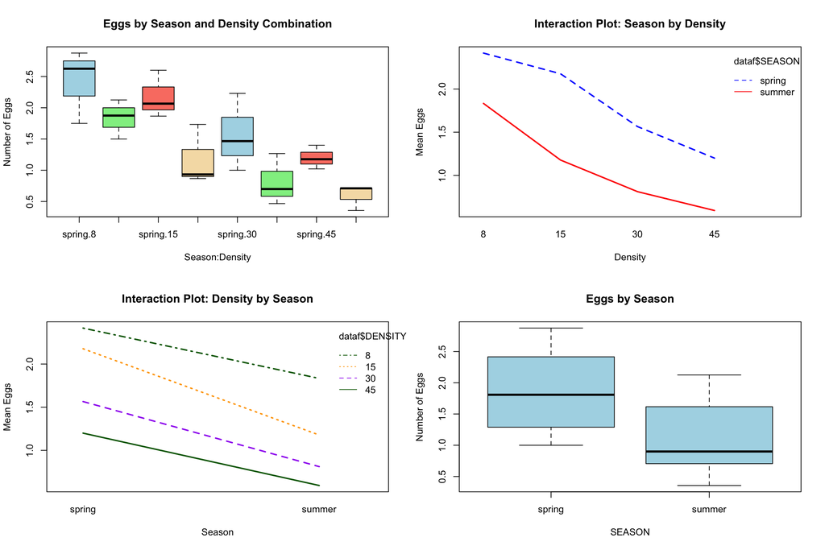

```r
# Create interaction plot
par(mfrow=c(2,2))

# Boxplot by combination
boxplot(EGGS~SEASON:DENSITY,
        col = c("lightblue", "lightgreen", "salmon", "wheat"),
        data = dataf,
        main = "Eggs by Season and Density Combination",
        xlab = "Season:Density",
        ylab = "Number of Eggs")

# Interaction plot - Season as factor
interaction.plot(dataf$DENSITY, dataf$SEASON, dataf$EGGS,
                main = "Interaction Plot: Season by Density",
                xlab = "Density", ylab = "Mean Eggs",
                col = c("blue", "red"), lwd = 2)

# Interaction plot - Density as factor
interaction.plot(dataf$SEASON, dataf$DENSITY, dataf$EGGS,
                main = "Interaction Plot: Density by Season",
                xlab = "Season", ylab = "Mean Eggs",
                col = c("darkgreen", "orange", "purple"), lwd = 2)

# Boxplot by individual factors
boxplot(EGGS~SEASON, data = dataf, col = "lightblue",
        main = "Eggs by Season", ylab = "Number of Eggs")
```

**Interpreting interaction plots:** - Parallel lines = no interaction - Non-parallel lines = interaction present - Crossing lines = strong interaction

### Model Comparison and Selection

Let’s compare our models using AIC (Akaike Information Criterion):

```r
# Compare models
models <- list(
  "Season only" = aov.season,
  "Density only" = aov.dens,
  "Additive" = aov.2w,
  "Interaction" = aov.int,
  "Intercept-only" = aov.intonly
)

# Calculate AIC for each model
aic_values <- sapply(models, AIC)
aic_table <- data.frame(
  Model = names(aic_values),
  AIC = aic_values,
  Delta_AIC = aic_values - min(aic_values)
)
aic_table[order(aic_table$AIC),]
```

```
##                         Model      AIC Delta_AIC
## Additive             Additive 30.82889  0.000000
## Interaction       Interaction 35.50973  4.680839
## Intercept-only Intercept-only 35.50973  4.680839
## Density only     Density only 46.12111 15.292221
## Season only       Season only 48.80873 17.979842
```

The model with the lowest AIC is generally preferred, with differences > 2 being meaningful.

### Post-hoc Tests

Since we have significant main effects, let’s examine pairwise differences:

```r
# Tukey HSD for the interaction model
TukeyHSD(aov.int)
```

```
##   Tukey multiple comparisons of means
##     95% family-wise confidence level
##
## Fit: aov(formula = EGGS ~ SEASON * DENSITY, data = dataf)
##
## $SEASON
##                 diff      lwr        upr     p adj
## summer-spring -0.736 -1.10538 -0.3666196 0.0006453
##
## $DENSITY
##             diff        lwr         upr     p adj
## 15-8  -0.4475000 -1.1525067  0.25750672 0.3020713
## 30-8  -0.9366667 -1.6416734 -0.23165995 0.0076800
## 45-8  -1.2288333 -1.9338401 -0.52382662 0.0006998
## 30-15 -0.4891667 -1.1941734  0.21584005 0.2342310
## 45-15 -0.7813333 -1.4863401 -0.07632662 0.0273273
## 45-30 -0.2921667 -0.9971734  0.41284005 0.6441191
##
## $`SEASON:DENSITY`
##                           diff        lwr         upr     p adj
## summer:8-spring:8   -0.5833333 -1.7898501  0.62318341 0.7025671
## spring:15-spring:8  -0.2393333 -1.4458501  0.96718341 0.9962324
## summer:15-spring:8  -1.2390000 -2.4455167 -0.03248326 0.0419597
## spring:30-spring:8  -0.8513333 -2.0578501  0.35518341 0.2856238
## summer:30-spring:8  -1.6053333 -2.8118501 -0.39881659 0.0054858
## spring:45-spring:8  -1.2170000 -2.4235167 -0.01048326 0.0472578
## summer:45-spring:8  -1.8240000 -3.0305167 -0.61748326 0.0016303
## spring:15-summer:8   0.3440000 -0.8625167  1.55051674 0.9699272
## summer:15-summer:8  -0.6556667 -1.8621834  0.55085008 0.5803457
## spring:30-summer:8  -0.2680000 -1.4745167  0.93851674 0.9925771
## summer:30-summer:8  -1.0220000 -2.2285167  0.18451674 0.1300342
## spring:45-summer:8  -0.6336667 -1.8401834  0.57285008 0.6178730
## summer:45-summer:8  -1.2406667 -2.4471834 -0.03414992 0.0415823
## summer:15-spring:15 -0.9996667 -2.2061834  0.20685008 0.1450778
## spring:30-spring:15 -0.6120000 -1.8185167  0.59451674 0.6546904
## summer:30-spring:15 -1.3660000 -2.5725167 -0.15948326 0.0208894
## spring:45-spring:15 -0.9776667 -2.1841834  0.22885008 0.1613268
## summer:45-spring:15 -1.5846667 -2.7911834 -0.37814992 0.0061579
## spring:30-summer:15  0.3876667 -0.8188501  1.59418341 0.9446738
## summer:30-summer:15 -0.3663333 -1.5728501  0.84018341 0.9583182
## spring:45-summer:15  0.0220000 -1.1845167  1.22851674 1.0000000
## summer:45-summer:15 -0.5850000 -1.7915167  0.62151674 0.6998230
## summer:30-spring:30 -0.7540000 -1.9605167  0.45251674 0.4194243
## spring:45-spring:30 -0.3656667 -1.5721834  0.84085008 0.9587034
## summer:45-spring:30 -0.9726667 -2.1791834  0.23385008 0.1652262
## spring:45-summer:30  0.3883333 -0.8181834  1.59485008 0.9442053
## summer:45-summer:30 -0.2186667 -1.4251834  0.98785008 0.9978410
## summer:45-spring:45 -0.6070000 -1.8135167  0.59951674 0.6631287
```

```r
# For a more detailed view of main effects
TukeyHSD(aov.int, which = "SEASON")
```

```
##   Tukey multiple comparisons of means
##     95% family-wise confidence level
##
## Fit: aov(formula = EGGS ~ SEASON * DENSITY, data = dataf)
##
## $SEASON
##                 diff      lwr        upr     p adj
## summer-spring -0.736 -1.10538 -0.3666196 0.0006453
```

```r
TukeyHSD(aov.int, which = "DENSITY")
```

```
##   Tukey multiple comparisons of means
##     95% family-wise confidence level
##
## Fit: aov(formula = EGGS ~ SEASON * DENSITY, data = dataf)
##
## $DENSITY
##             diff        lwr         upr     p adj
## 15-8  -0.4475000 -1.1525067  0.25750672 0.3020713
## 30-8  -0.9366667 -1.6416734 -0.23165995 0.0076800
## 45-8  -1.2288333 -1.9338401 -0.52382662 0.0006998
## 30-15 -0.4891667 -1.1941734  0.21584005 0.2342310
## 45-15 -0.7813333 -1.4863401 -0.07632662 0.0273273
## 45-30 -0.2921667 -0.9971734  0.41284005 0.6441191
```

### Model Assumptions

Let’s check our model assumptions:

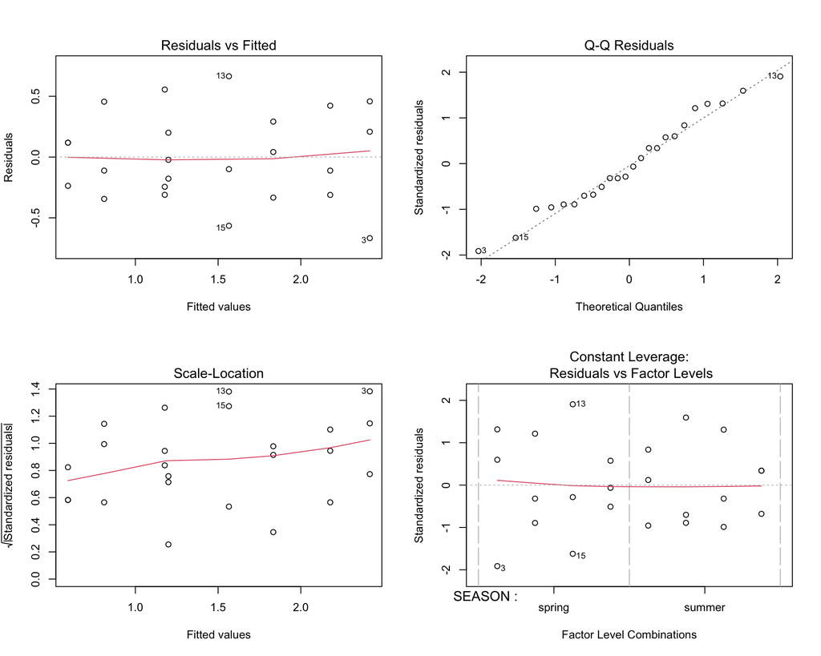

```r
par(mfrow=c(2,2))
plot(aov.int)
```

```r
# Additional tests
# Homogeneity of variances (Levene's test)
leveneTest(EGGS ~ SEASON * DENSITY, data = dataf)
```

```
## Levene's Test for Homogeneity of Variance (center = median)
##       Df F value Pr(>F)
## group  7  0.3337 0.9268
##       16
```

```r
# Normality of residuals (Shapiro-Wilk test)
shapiro.test(residuals(aov.int))
```

```
##
##  Shapiro-Wilk normality test
##
## data:  residuals(aov.int)
## W = 0.97373, p-value = 0.7587
```

### Effect Sizes

Understanding statistical significance is important, but effect sizes help us understand practical significance:

```r
# Calculate eta-squared (proportion of variance explained)
ss_table <- summary(aov.int)[[1]]
ss_total <- sum(ss_table[,"Sum Sq"])

eta_squared <- ss_table[1:3,"Sum Sq"] / ss_total
names(eta_squared) <- rownames(ss_table)[1:3]

print("Eta-squared (effect sizes):")
```

```
## [1] "Eta-squared (effect sizes):"
```

```r
eta_squared
```

```
## SEASON         DENSITY        SEASON:DENSITY
##     0.27985826     0.45499379     0.01418058
```

**Effect size interpretation:** - Small: η² ≈ 0.01 - Medium: η² ≈ 0.06  
- Large: η² ≈ 0.14

### Including Error Terms (Mixed Effects)

In some cases, we might want to treat one factor as random. Let’s assume DENSITY represents randomly selected density levels from a broader population:

```r
# Treating DENSITY as a random factor
aov.mixed <- aov(EGGS ~ SEASON + Error(DENSITY), data = dataf)
summary(aov.mixed)
```

```
##
## Error: DENSITY
##           Df Sum Sq Mean Sq F value Pr(>F)
## Residuals  3  5.284   1.761
##
## Error: Within
##           Df Sum Sq Mean Sq F value   Pr(>F)
## SEASON     1  3.250   3.250   20.05 0.000258 ***
## Residuals 19  3.079   0.162
## ---
## Signif. codes:  0 '***' 0.001 '**' 0.01 '*' 0.05 '.' 0.1 ' ' 1
```

**Interpretation:** This analysis examines the effects of season on egg number, while accounting for the random variation among density levels. This approach is useful when we want to generalize beyond the specific density levels tested.

### Advanced: Using Type II/III ANOVA

For unbalanced designs or when order matters, we might want Type II or III ANOVA:

```r
# Type II ANOVA (recommended for balanced designs without interactions)
Anova(aov.int, type = "II")
```

```
## Anova Table (Type II tests)
##
## Response: EGGS
##                Sum Sq Df F value    Pr(>F)
## SEASON         3.2502  1 17.8419 0.0006453 ***
## DENSITY        5.2841  3  9.6691 0.0007041 ***
## SEASON:DENSITY 0.1647  3  0.3014 0.8239545
## Residuals      2.9146 16
## ---
## Signif. codes:  0 '***' 0.001 '**' 0.01 '*' 0.05 '.' 0.1 ' ' 1
```

```r
# Type III ANOVA (for unbalanced designs or when interactions are present)
Anova(aov.int, type = "III")
```

```
## Anova Table (Type III tests)
##
## Response: EGGS
##                 Sum Sq Df F value    Pr(>F)
## (Intercept)    17.5208  1 96.1809 3.599e-08 ***
## SEASON          0.5104  1  2.8019   0.11358
## DENSITY         2.7954  3  5.1152   0.01136 *
## SEASON:DENSITY  0.1647  3  0.3014   0.82395
## Residuals       2.9146 16
## ---
## Signif. codes:  0 '***' 0.001 '**' 0.01 '*' 0.05 '.' 0.1 ' ' 1
```

As you can see, results are different between type II and type III. Therefore, it’s critical to wisely choose the most appropriate model for your data.

## Final thoughts

Nested and Factorial ANOVA designs allow us to analyze more complex experiments and obtain reliable estimates taking multiple sources of variation into consideration. Key considerations include:

1. **Design planning:** Think about your factors (fixed vs. random) and their relationships (nested vs. crossed) before data collection
2. **Model selection:** Use appropriate models based on your experimental design and research questions
3. **Assumption checking:** Always verify that your data meets ANOVA assumptions
4. **Effect sizes:** Don’t rely solely on p-values; consider practical significance
5. **Visualization:** Plots help interpret complex interactions and communicate results effectively

Remember that if you perform a flawed design and collect field data, analyzing such data will be difficult and your results might be unreliable or not generalizable to your intended population.

Licensing Creative Commons License

Licensed under a Creative Commons Attribution-ShareAlike 4.0 International License.  
2025 - Francisco E. Fontúrbel